# HW4_Solution

This assumption is not likely to hold since we would expect fuel prices to vary over time, which leads to costs changing over time. This can be improved by including year fixed effects, which will capture changes over time that are common to all states.

```r
# We can also recover the state fixed effects
statefe <- as.data.table(getfe(reg2_rw))
statefe[,state := idx]
# Merge it into the data table, as well as a treatment effect
dt <- merge(dt, statefe, by = "state")
dt[, treatment_effect := treated*reg2_rw$coefficients[1,1]]
# The calculated residuals and the model residuals are 'different' because of floating point error
# https://stackoverflow.com/questions/2100490/floating-point-inaccuracy-examples
# https://blog.penjee.com/famous-number-computing-errors/  Rocket explosions as promised
dt[,residuals := residential - treatment_effect - effect]
dt[, residuals2 := reg2_rw$residuals]
dt[!residuals == residuals2,.(residuals, residuals2)]
```

```
##        residuals  residuals2
##   1: -1.30415523 -1.30415523
##   2: -0.49415523 -0.49415523
##   3: -0.21415523 -0.21415523
##   4:  0.01584477  0.01584477
##   5:  0.14584477  0.14584477
##  ---
## 403:  0.90705422  0.90705422
## 404:  1.17705422  1.17705422
## 405:  1.16705422  1.16705422
## 406:  1.35705422  1.35705422
## 407:  1.53705422  1.53705422
```

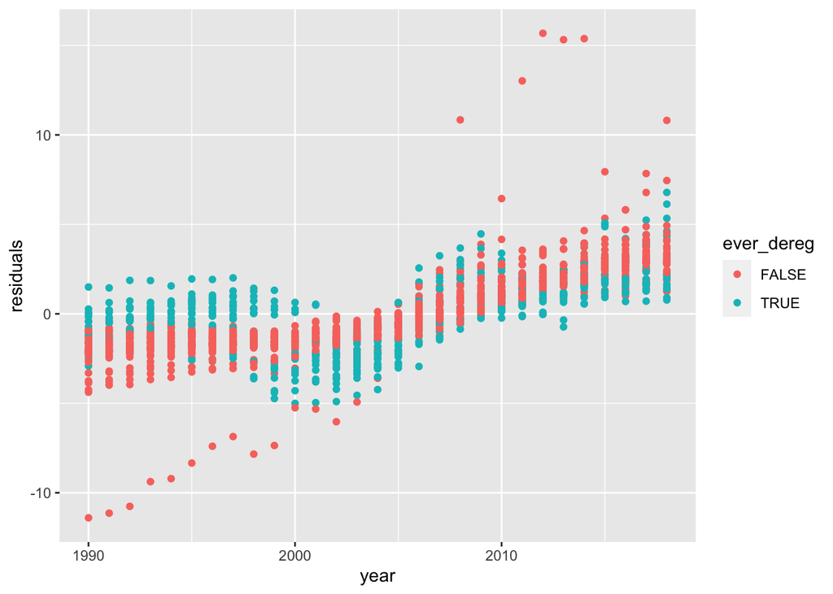

```r
# Residuals aren't random around 0, they exhibit differential trends that vary across states that we wrongly would attribute to deregulation
ggplot(dt) +
  geom_point(aes(year, residuals, colour =ever_dereg))
```

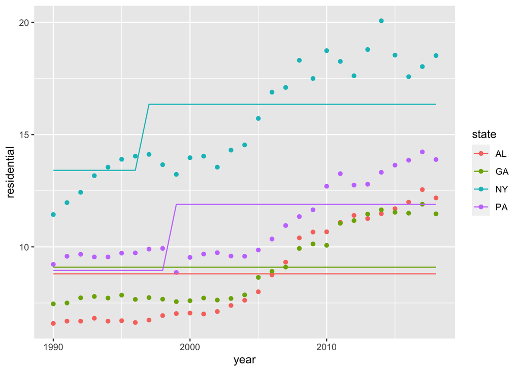

```r
# What does the implied model look like for a couple states?
# Observe that GA, NY, PA and AL all have similar trends conditional on the starting point.
# But in NY and PA, we (wrongfully) attribute this to deregulation
dt[, residential_predict := reg2_rw$fitted.values]
ggplot(dt[state %in% c('GA','NY',"PA","AL")]) +
  geom_point(aes(year, residential, colour = state))  +
  geom_line(aes(year, residential_predict, colour = state))
```

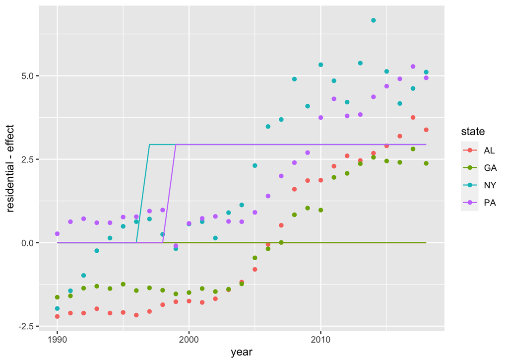

```r
# Plot the same graph NET of fixed effects.
ggplot(dt[state %in% c('GA','NY',"PA","AL")]) +
  geom_point(aes(year, residential - effect, colour = state))  +
  geom_line(aes(year, residential_predict - effect, colour = state))
```

7. Now run the same regressions but adding state and year fixed effects. What do you find? (Make sure to cluster your standard errors at the state level)

```r
reg3_rw <- felm(residential ~ treated| state + as.factor(year) | 0 | state, data = data[industry_sector == "Total Electric Industry"])
reg3_cw <- felm(commercial ~ treated| state + as.factor(year) | 0 | state, data = data[industry_sector == "Total Electric Industry"])
reg3_iw <- felm(industrial ~ treated| state + as.factor(year) | 0 | state, data = data[industry_sector == "Total Electric Industry"])

stargazer(reg3_rw, reg3_cw, reg3_iw, type="text")
```

```
##
## =================================================================
##                                        Dependent variable:
##                                 ---------------------------------
##                                 residential commercial industrial
##                                     (1)        (2)        (3)
## -----------------------------------------------------------------
## treated                            0.052      0.038      0.260
##                                   (0.421)    (0.390)    (0.354)
##
## -----------------------------------------------------------------
## Observations                       1,508      1,508      1,508
## R2                                 0.877      0.850      0.822
## Adjusted R2                        0.870      0.842      0.812
## Residual Std. Error (df = 1427)    1.338      1.271      1.291
## =================================================================
## Note:                                 *p<0.1; **p<0.05; ***p<0.01
```

Adding year fixed effects makes the difference between regulated and deregulated states disappear.

8. What is the underlying assumption for the above estimates to be interpreted causally? Is this assumption reasonable? Explain and use data to support your answer if you can.

Here the assumption is that there are no time varying variables that affect prices in different states differently, which is known as common trends. We allow for differences across states using state fixed effects, and differences across time that are common across states using year fixed effects, but not time varying differences between states. Though this specification is more robust than the previous ones, it is still not enough to capture causal effects cleanly. The common trends assumption is not likely to hold since there are some time varying variables that affect different states differently, like fuel prices. There have been significant changes in fuel prices and these have different effects depending on the fuel mix of each state. Additionally, there are some policies implemented at the state level that could lead to time varying differences across states, like renewable portfolio standards. That said, it still looks like deregulation did not have a strong negative effects on prices, but we would need a better identification strategy to confirm the effect.

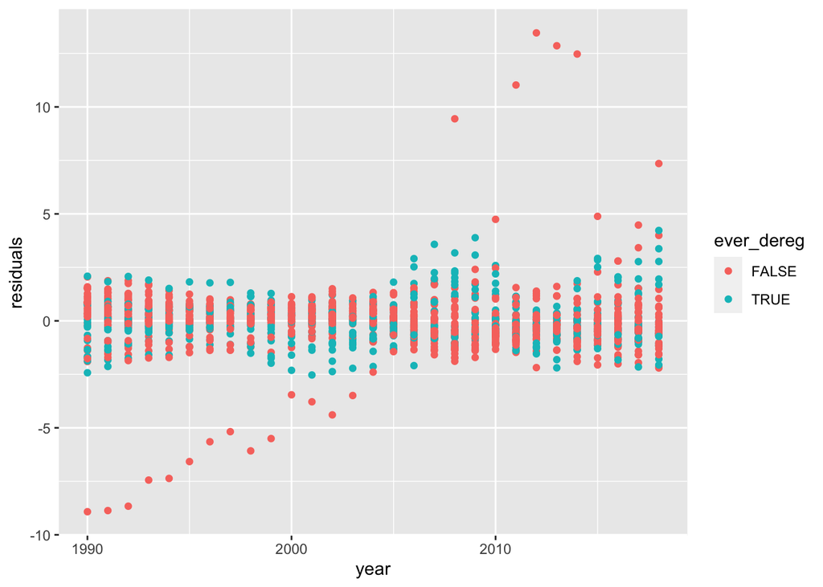

```r
# Residuals now look mostly random-ish about 0, except for a couple of states
dt[, residuals := reg3_rw$residuals]
ggplot(dt) +
  geom_point(aes(year, residuals, colour =ever_dereg))
```

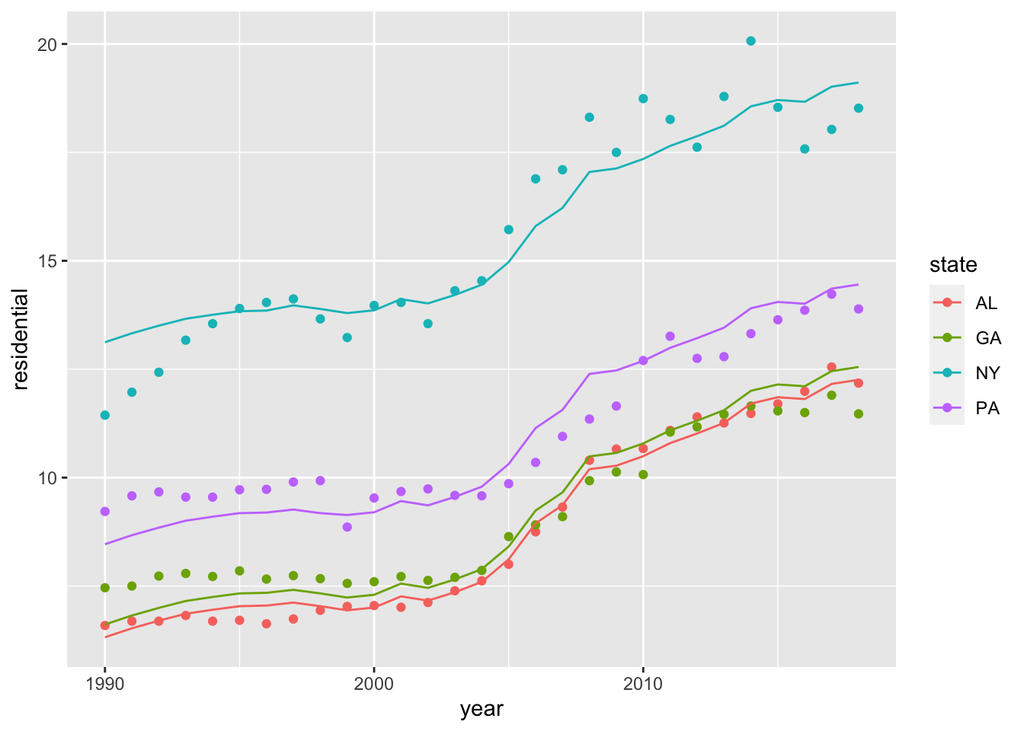

```r
# What does the implied model look like for a couple states?
# Observe that GA, NY, PA and AL all have similar trends conditional on the starting point.
# But in NY and PA, we (wrongfully) attribute this to deregulation
dt[, residential_predict := reg3_rw$fitted.values]
ggplot(dt[state %in% c('GA','NY',"PA","AL")]) +
  geom_point(aes(year, residential, colour = state))  +
  geom_line(aes(year, residential_predict, colour = state))
```